# Reproducible Research: Peer Assessment 1

## Loading and preprocessing the data

```r
library('dplyr')
```

```r
library('ggplot2')
library('scales')
library('stringr')

setwd('~/git/data-science/RepData_PeerAssessment1/')

data <- read.csv('activity.csv', as.is = TRUE)
data$date <- as.POSIXct(data$date)
```

## What is mean total number of steps taken per day?

*1. Calculate the total number of steps taken per day.*

The total number of steps taken per day is calculated and shown below.

```r
total_steps_per_day <- data %>%
  na.omit() %>%
  group_by(date) %>%
  summarize(steps = sum(steps))

print(total_steps_per_day)
```

```
## Source: local data frame [53 x 2]
##
##          date steps
## 1  2012-10-02   126
## 2  2012-10-03 11352
## 3  2012-10-04 12116
## 4  2012-10-05 13294
## 5  2012-10-06 15420
## 6  2012-10-07 11015
## 7  2012-10-09 12811
## 8  2012-10-10  9900
## 9  2012-10-11 10304
## 10 2012-10-12 17382
## ..        ...   ...
```

*2. Make a histogram of the total number of steps taken each day.*

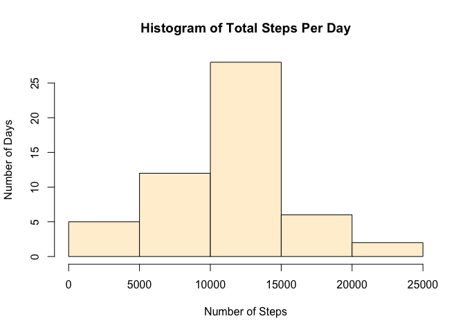

```r
hist(total_steps_per_day$steps,
     col = "papayaWhip",
     main = "Histogram of Total Steps Per Day",
     xlab = "Number of Steps",
     ylab = "Number of Days"
    )
```

*3. Calculate and report the mean and median of the total number of steps taken per day.*

The mean and median of the total number of steps taken per day is calculated and shown below.

```r
total_steps_per_day %>%
  summarize(mean_steps_per_day = mean(steps),
            median_steps_per_day = median(steps))
```

```
## Source: local data frame [1 x 2]
##
##   mean_steps_per_day median_steps_per_day
## 1           10766.19                10765
```

## What is the average daily activity pattern?

*1. Make a time series plot of the 5-minute interval (x-axis) and the average number of steps taken, averaged across all days (y-axis).*

We first need to make a new column that contains the interval as an actual time instead of just an integer so that we don’t have gaps in our graph between `55` -> `100`, `155` -> `200`, etc. We’ll use today’s date as the date for every entry since it will be easier to group by the time and we don’t care about the date for this graph.

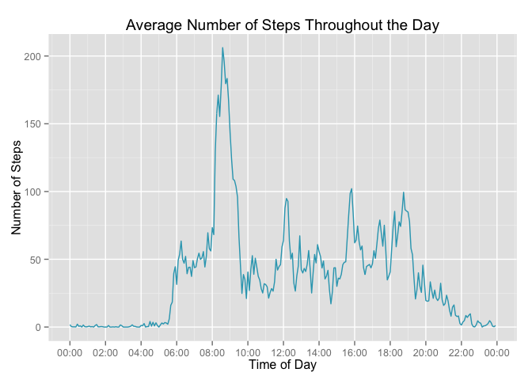

```r
# Convert the interval value to a datetime
to_hhmm <- function(t) {
  first <- str_pad(t, 4, pad = 0)
  hhmm <- strptime((paste(substr(first, 1, 2), ":", substr(first, 3, 4), sep = "")), "%H:%M")

  hhmm
}

avg_steps_per_interval <- data %>%
  na.omit() %>%
  mutate(interval_time = as.POSIXct(to_hhmm(interval))) %>%
  group_by(interval_time) %>%
  summarize(avg_steps = mean(steps))

ggplot(data = avg_steps_per_interval, aes(x = interval_time, y = avg_steps)) +
  geom_line(color = "#31A5BD") +
  scale_x_datetime(labels = date_format("%H:%M"), breaks = "2 hour") +
  labs(x = "Time of Day", y = "Number of Steps") +
  ggtitle("Average Number of Steps Throughout the Day")
```

*2. Which 5-minute interval, on average across all the days in the dataset, contains the maximum number of steps?*

The 5-minute interval with the maximum number of steps is calculated and shown below.

```r
sorted_by_steps <- avg_steps_per_interval %>%
  mutate(interval_time = format(interval_time, "%H:%M")) %>%
  arrange(desc(avg_steps))

head(sorted_by_steps, 1)
```

```
## Source: local data frame [1 x 2]
##
##   interval_time avg_steps
## 1         08:35  206.1698
```

## Inputing missing values

*1. Calculate and report the total number of missing values in the dataset (i.e. the total number of rows with NAs).*

The number of incomplete cases is calculated and shown below.

```r
nrow(data) - sum(complete.cases(data))
```

```
## [1] 2304
```

*2. Devise a strategy for filling in all of the missing values in the dataset. The strategy does not need to be sophisticated.*

My strategy is to fill NA values with the mean value for that given interval calculated from all of the days in the dataset.

```r
avg_steps_per_interval <- data %>%
  na.omit() %>%
  group_by(interval) %>%
  summarize(avg_steps = mean(steps))
```

*3. Create a new dataset that is equal to the original dataset but with the missing data filled in.*

Join the original dataset to the average steps per interval dataset calculated above. The two datasets are joined on the interval column. Then, create a new column that is either the value of the steps column, or the average step count for that interval if the steps column is equal to NA.

```r
filled <- data %>%
  left_join(avg_steps_per_interval) %>%
  mutate(filled_steps = ifelse(is.na(steps), avg_steps, steps))
```

*4. Make a histogram of the total number of steps taken each day and calculate and report the mean and median total number of steps taken per day. Do these values differ from the estimates from the first part of the assignment? What is the impact of inputing missing data on the estimates of the total daily number of steps?*

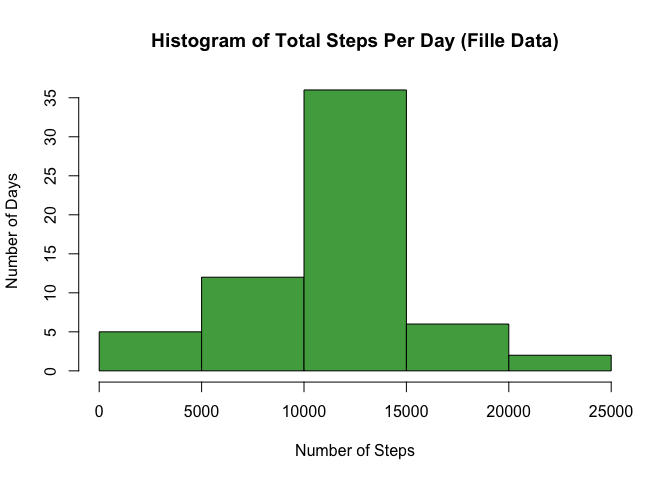

```r
filled_total_steps_per_day <- filled %>%
  group_by(date) %>%
  summarize(total_steps = sum(filled_steps))

hist(filled_total_steps_per_day$total_steps,
     col = "#50A84D",
     main = "Histogram of Total Steps Per Day (Fille Data)",
     xlab = "Number of Steps",
     ylab = "Number of Days" )
```

```r
filled_total_steps_per_day %>%
  summarize(mean_steps_per_day = mean(total_steps),
            median_steps_per_day = median(total_steps))
```

```
## Source: local data frame [1 x 2]
##
##   mean_steps_per_day median_steps_per_day
## 1           10766.19             10766.19
```

## Are there differences in activity patterns between weekdays and weekends?

*1. Create a new factor variable in the dataset with two levels – “weekday” and “weekend” indicating whether a given date is a weekday or weekend day.*

Create a datetime column based on the date and interval columns to determine if each row is an observation for a weekend day or weekday.

```r
to_datetime <- function(t, d) {
  padded <- str_pad(t, 4, pad = 0)
  datetime <- strptime(
    paste(d, " ", substr(padded, 1, 2), ":", substr(padded, 3, 4), sep = ""), "%Y-%m-%d %H:%M"
  )

  datetime
}

data_w_day_type <- filled %>%
  mutate(interval_time = as.POSIXct(to_datetime(interval, date))) %>%
  mutate(day_type = as.factor(ifelse(as.numeric(format(interval_time, '%u')) <= 5, "Weekday", "Weekend")))
```

*2. Make a panel plot containing a time series plot (i.e. type = “l”) of the 5-minute interval (x-axis) and the average number of steps taken, averaged across all weekday days or weekend days (y-axis).*

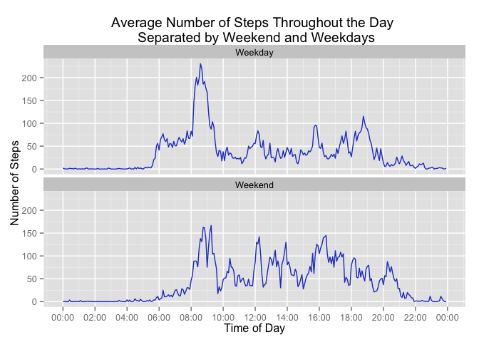

```r
avg_steps_per_interval_by_day_type <- data_w_day_type %>%
  mutate(hhmm = as.POSIXct(to_hhmm(interval))) %>%
  group_by(hhmm, day_type) %>%
  summarize(avg_steps_by_hhmm_by_day_type = mean(filled_steps))

ggplot(data = avg_steps_per_interval_by_day_type, aes(x = hhmm, y = avg_steps_by_hhmm_by_day_type)) +
  geom_line(color = "#2545CF") +
  labs(x = "Time of Day", y = "Number of Steps") +
  facet_wrap(~day_type, ncol=1) +
  scale_x_datetime(labels = date_format("%H:%M"), breaks = "2 hour") +
  ggtitle("Average Number of Steps Throughout the Day \n Separated by Weekend and Weekdays")
```